# Risk Factor Analysis

## Outcome Variable

**Outcome Variable:** whz

## Predictor Variables

**Intervention Variable:** predfeed36

**Adjustment Set:**

unadjusted

## Stratifying Variables

The analysis was stratified on these variable(s):

- agecat
- studyid
- country

## Data Summary

| agecat | studyid | country | predfeed36 | n_cell | n |
| --- | --- | --- | --- | --- | --- |
| Birth | ki0047075b-MAL-ED | BANGLADESH | 1 | 69 | 208 |
| Birth | ki0047075b-MAL-ED | BANGLADESH | 0 | 139 | 208 |
| Birth | ki0047075b-MAL-ED | BRAZIL | 1 | 7 | 62 |
| Birth | ki0047075b-MAL-ED | BRAZIL | 0 | 55 | 62 |
| Birth | ki0047075b-MAL-ED | INDIA | 1 | 4 | 40 |
| Birth | ki0047075b-MAL-ED | INDIA | 0 | 36 | 40 |
| Birth | ki0047075b-MAL-ED | NEPAL | 1 | 1 | 25 |
| Birth | ki0047075b-MAL-ED | NEPAL | 0 | 24 | 25 |
| Birth | ki0047075b-MAL-ED | PERU | 1 | 57 | 218 |
| Birth | ki0047075b-MAL-ED | PERU | 0 | 161 | 218 |
| Birth | ki0047075b-MAL-ED | SOUTH AFRICA | 1 | 2 | 104 |
| Birth | ki0047075b-MAL-ED | SOUTH AFRICA | 0 | 102 | 104 |
| Birth | ki0047075b-MAL-ED | TANZANIA, UNITED REPUBLIC OF | 1 | 0 | 111 |
| Birth | ki0047075b-MAL-ED | TANZANIA, UNITED REPUBLIC OF | 0 | 111 | 111 |
| Birth | ki1000109-EE | PAKISTAN | 1 | 2 | 6 |
| Birth | ki1000109-EE | PAKISTAN | 0 | 4 | 6 |
| Birth | ki1113344-GMS-Nepal | NEPAL | 1 | 396 | 491 |
| Birth | ki1113344-GMS-Nepal | NEPAL | 0 | 95 | 491 |
| Birth | kiGH5241-JiVitA-3 | BANGLADESH | 1 | 6746 | 8619 |
| Birth | kiGH5241-JiVitA-3 | BANGLADESH | 0 | 1873 | 8619 |
| Birth | kiGH5241-JiVitA-4 | BANGLADESH | 1 | 1714 | 2128 |
| Birth | kiGH5241-JiVitA-4 | BANGLADESH | 0 | 414 | 2128 |
| 6 months | ki0047075b-MAL-ED | BANGLADESH | 1 | 81 | 240 |
| 6 months | ki0047075b-MAL-ED | BANGLADESH | 0 | 159 | 240 |
| 6 months | ki0047075b-MAL-ED | BRAZIL | 1 | 25 | 209 |
| 6 months | ki0047075b-MAL-ED | BRAZIL | 0 | 184 | 209 |
| 6 months | ki0047075b-MAL-ED | INDIA | 1 | 17 | 233 |
| 6 months | ki0047075b-MAL-ED | INDIA | 0 | 216 | 233 |
| 6 months | ki0047075b-MAL-ED | NEPAL | 1 | 8 | 235 |
| 6 months | ki0047075b-MAL-ED | NEPAL | 0 | 227 | 235 |
| 6 months | ki0047075b-MAL-ED | PERU | 1 | 72 | 272 |
| 6 months | ki0047075b-MAL-ED | PERU | 0 | 200 | 272 |
| 6 months | ki0047075b-MAL-ED | SOUTH AFRICA | 1 | 3 | 250 |
| 6 months | ki0047075b-MAL-ED | SOUTH AFRICA | 0 | 247 | 250 |
| 6 months | ki0047075b-MAL-ED | TANZANIA, UNITED REPUBLIC OF | 1 | 5 | 243 |
| 6 months | ki0047075b-MAL-ED | TANZANIA, UNITED REPUBLIC OF | 0 | 238 | 243 |
| 6 months | ki1000109-EE | PAKISTAN | 1 | 4 | 9 |
| 6 months | ki1000109-EE | PAKISTAN | 0 | 5 | 9 |
| 6 months | ki1000304b-SAS-FoodSuppl | INDIA | 1 | 0 | 168 |
| 6 months | ki1000304b-SAS-FoodSuppl | INDIA | 0 | 168 | 168 |
| 6 months | ki1113344-GMS-Nepal | NEPAL | 1 | 422 | 527 |
| 6 months | ki1113344-GMS-Nepal | NEPAL | 0 | 105 | 527 |
| 6 months | ki1148112-LCNI-5 | MALAWI | 1 | 47 | 272 |
| 6 months | ki1148112-LCNI-5 | MALAWI | 0 | 225 | 272 |
| 6 months | kiGH5241-JiVitA-3 | BANGLADESH | 1 | 6576 | 8535 |
| 6 months | kiGH5241-JiVitA-3 | BANGLADESH | 0 | 1959 | 8535 |
| 6 months | kiGH5241-JiVitA-4 | BANGLADESH | 1 | 3252 | 4188 |
| 6 months | kiGH5241-JiVitA-4 | BANGLADESH | 0 | 936 | 4188 |
| 24 months | ki0047075b-MAL-ED | BANGLADESH | 1 | 69 | 212 |
| 24 months | ki0047075b-MAL-ED | BANGLADESH | 0 | 143 | 212 |
| 24 months | ki0047075b-MAL-ED | BRAZIL | 1 | 20 | 169 |
| 24 months | ki0047075b-MAL-ED | BRAZIL | 0 | 149 | 169 |
| 24 months | ki0047075b-MAL-ED | INDIA | 1 | 17 | 224 |
| 24 months | ki0047075b-MAL-ED | INDIA | 0 | 207 | 224 |
| 24 months | ki0047075b-MAL-ED | NEPAL | 1 | 8 | 227 |
| 24 months | ki0047075b-MAL-ED | NEPAL | 0 | 219 | 227 |
| 24 months | ki0047075b-MAL-ED | PERU | 1 | 53 | 201 |
| 24 months | ki0047075b-MAL-ED | PERU | 0 | 148 | 201 |
| 24 months | ki0047075b-MAL-ED | SOUTH AFRICA | 1 | 3 | 235 |
| 24 months | ki0047075b-MAL-ED | SOUTH AFRICA | 0 | 232 | 235 |
| 24 months | ki0047075b-MAL-ED | TANZANIA, UNITED REPUBLIC OF | 1 | 4 | 213 |
| 24 months | ki0047075b-MAL-ED | TANZANIA, UNITED REPUBLIC OF | 0 | 209 | 213 |
| 24 months | ki1000109-EE | PAKISTAN | 1 | 0 | 3 |
| 24 months | ki1000109-EE | PAKISTAN | 0 | 3 | 3 |
| 24 months | ki1113344-GMS-Nepal | NEPAL | 1 | 362 | 445 |
| 24 months | ki1113344-GMS-Nepal | NEPAL | 0 | 83 | 445 |
| 24 months | ki1148112-LCNI-5 | MALAWI | 1 | 34 | 184 |
| 24 months | ki1148112-LCNI-5 | MALAWI | 0 | 150 | 184 |
| 24 months | kiGH5241-JiVitA-3 | BANGLADESH | 1 | 3320 | 4317 |
| 24 months | kiGH5241-JiVitA-3 | BANGLADESH | 0 | 997 | 4317 |
| 24 months | kiGH5241-JiVitA-4 | BANGLADESH | 1 | 3144 | 4035 |
| 24 months | kiGH5241-JiVitA-4 | BANGLADESH | 0 | 891 | 4035 |

The following strata were considered:

- agecat: 24 months, studyid: ki0047075b-MAL-ED, country: BANGLADESH
- agecat: 24 months, studyid: ki0047075b-MAL-ED, country: BRAZIL
- agecat: 24 months, studyid: ki0047075b-MAL-ED, country: INDIA
- agecat: 24 months, studyid: ki0047075b-MAL-ED, country: NEPAL
- agecat: 24 months, studyid: ki0047075b-MAL-ED, country: PERU
- agecat: 24 months, studyid: ki0047075b-MAL-ED, country: SOUTH AFRICA
- agecat: 24 months, studyid: ki0047075b-MAL-ED, country: TANZANIA, UNITED REPUBLIC OF
- agecat: 24 months, studyid: ki1000109-EE, country: PAKISTAN
- agecat: 24 months, studyid: ki1113344-GMS-Nepal, country: NEPAL
- agecat: 24 months, studyid: ki1148112-LCNI-5, country: MALAWI
- agecat: 24 months, studyid: kiGH5241-JiVitA-3, country: BANGLADESH
- agecat: 24 months, studyid: kiGH5241-JiVitA-4, country: BANGLADESH
- agecat: 6 months, studyid: ki0047075b-MAL-ED, country: BANGLADESH
- agecat: 6 months, studyid: ki0047075b-MAL-ED, country: BRAZIL
- agecat: 6 months, studyid: ki0047075b-MAL-ED, country: INDIA
- agecat: 6 months, studyid: ki0047075b-MAL-ED, country: NEPAL
- agecat: 6 months, studyid: ki0047075b-MAL-ED, country: PERU
- agecat: 6 months, studyid: ki0047075b-MAL-ED, country: SOUTH AFRICA
- agecat: 6 months, studyid: ki0047075b-MAL-ED, country: TANZANIA, UNITED REPUBLIC OF
- agecat: 6 months, studyid: ki1000109-EE, country: PAKISTAN
- agecat: 6 months, studyid: ki1000304b-SAS-FoodSuppl, country: INDIA
- agecat: 6 months, studyid: ki1113344-GMS-Nepal, country: NEPAL
- agecat: 6 months, studyid: ki1148112-LCNI-5, country: MALAWI
- agecat: 6 months, studyid: kiGH5241-JiVitA-3, country: BANGLADESH
- agecat: 6 months, studyid: kiGH5241-JiVitA-4, country: BANGLADESH
- agecat: Birth, studyid: ki0047075b-MAL-ED, country: BANGLADESH
- agecat: Birth, studyid: ki0047075b-MAL-ED, country: BRAZIL
- agecat: Birth, studyid: ki0047075b-MAL-ED, country: INDIA
- agecat: Birth, studyid: ki0047075b-MAL-ED, country: NEPAL
- agecat: Birth, studyid: ki0047075b-MAL-ED, country: PERU
- agecat: Birth, studyid: ki0047075b-MAL-ED, country: SOUTH AFRICA
- agecat: Birth, studyid: ki0047075b-MAL-ED, country: TANZANIA, UNITED REPUBLIC OF
- agecat: Birth, studyid: ki1000109-EE, country: PAKISTAN
- agecat: Birth, studyid: ki1113344-GMS-Nepal, country: NEPAL
- agecat: Birth, studyid: kiGH5241-JiVitA-3, country: BANGLADESH
- agecat: Birth, studyid: kiGH5241-JiVitA-4, country: BANGLADESH

### Dropped Strata

Some strata were dropped due to rare outcomes:

- agecat: Birth, studyid: ki0047075b-MAL-ED, country: INDIA
- agecat: Birth, studyid: ki0047075b-MAL-ED, country: NEPAL
- agecat: Birth, studyid: ki0047075b-MAL-ED, country: SOUTH AFRICA
- agecat: Birth, studyid: ki0047075b-MAL-ED, country: TANZANIA, UNITED REPUBLIC OF
- agecat: Birth, studyid: ki1000109-EE, country: PAKISTAN
- agecat: 6 months, studyid: ki0047075b-MAL-ED, country: SOUTH AFRICA
- agecat: 6 months, studyid: ki1000109-EE, country: PAKISTAN
- agecat: 6 months, studyid: ki1000304b-SAS-FoodSuppl, country: INDIA
- agecat: 24 months, studyid: ki0047075b-MAL-ED, country: SOUTH AFRICA
- agecat: 24 months, studyid: ki0047075b-MAL-ED, country: TANZANIA, UNITED REPUBLIC OF
- agecat: 24 months, studyid: ki1000109-EE, country: PAKISTAN

## Methods Detail

We’re interested in the causal parameters $E[Y_a]$ for all values of $a \in \mathcal{A}$. These parameters represent the mean outcome if, possibly contrary to fact, we intervened to set all units to have $A=a$. Under the randomization and positivity assumptions, these are identified by the statistical parameters $\psi_a=E_W[E_{Y|A,W}(Y|A=a,W)]$. In addition, we’re interested in the mean of $Y$, $E[Y]$ under no intervention (the observed mean). We will estimate these parameters by using SuperLearner to fit the relevant likelihood factors – $E_{Y|A,W}(Y|A=a,W)$ and $p(A=a|W)$, and then updating our likelihood fit using a joint TMLE.

For unadjusted analyses ($W=\{\}$), initial likelihoods were estimated using Lrnr_glm to estimate the simple $E(Y|A)$ and Lrnr_mean to estimate $p(A)$. For adjusted analyses, a small library containing Lrnr_glmnet, Lrnr_xgboost, and Lrnr_mean was used.

Having estimated these parameters, we will then use the delta method to estimate relative risks and attributable risks relative to a prespecified baseline level of $A$.

# Results Detail

## Results Plots

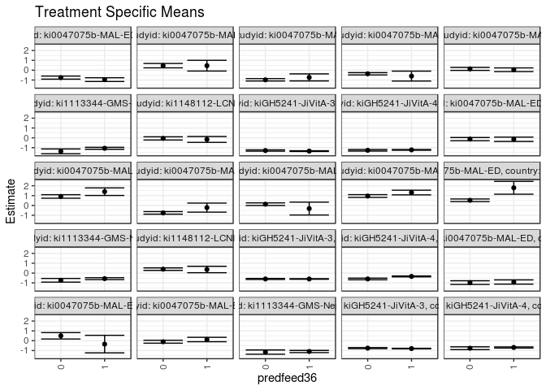

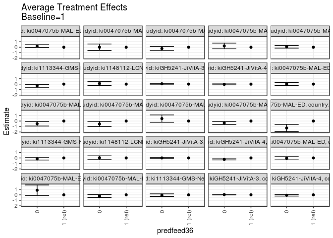

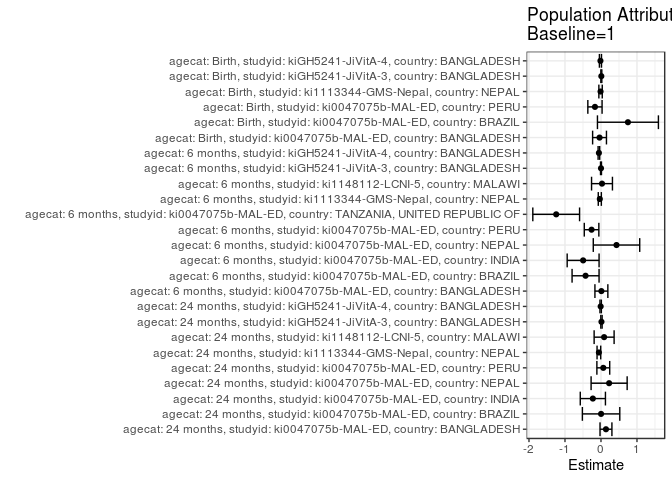

## Results Table

### Parameter: TSM

| agecat | studyid | country | intervention_level | baseline_level | estimate | ci_lower | ci_upper |
| --- | --- | --- | --- | --- | --- | --- | --- |
| Birth | ki0047075b-MAL-ED | BANGLADESH | 1 | NA | -0.9078986 | -1.1245741 | -0.6912230 |
| Birth | ki0047075b-MAL-ED | BANGLADESH | 0 | NA | -0.9680216 | -1.1570918 | -0.7789514 |
| Birth | ki0047075b-MAL-ED | BRAZIL | 1 | NA | -0.3457143 | -1.2397629 | 0.5483343 |
| Birth | ki0047075b-MAL-ED | BRAZIL | 0 | NA | 0.4981818 | 0.1725808 | 0.8237829 |
| Birth | ki0047075b-MAL-ED | PERU | 1 | NA | 0.1215789 | -0.1017661 | 0.3449240 |
| Birth | ki0047075b-MAL-ED | PERU | 0 | NA | -0.1050932 | -0.2518437 | 0.0416573 |
| Birth | ki1113344-GMS-Nepal | NEPAL | 1 | NA | -1.0968939 | -1.2083862 | -0.9854017 |
| Birth | ki1113344-GMS-Nepal | NEPAL | 0 | NA | -1.1572632 | -1.3736690 | -0.9408573 |
| Birth | kiGH5241-JiVitA-3 | BANGLADESH | 1 | NA | -0.7988378 | -0.8261061 | -0.7715695 |
| Birth | kiGH5241-JiVitA-3 | BANGLADESH | 0 | NA | -0.7546289 | -0.8090159 | -0.7002419 |
| Birth | kiGH5241-JiVitA-4 | BANGLADESH | 1 | NA | -0.6869720 | -0.7433958 | -0.6305482 |
| Birth | kiGH5241-JiVitA-4 | BANGLADESH | 0 | NA | -0.7636957 | -0.9048310 | -0.6225603 |
| 6 months | ki0047075b-MAL-ED | BANGLADESH | 1 | NA | -0.1466667 | -0.3653903 | 0.0720569 |
| 6 months | ki0047075b-MAL-ED | BANGLADESH | 0 | NA | -0.1297484 | -0.2898889 | 0.0303920 |
| 6 months | ki0047075b-MAL-ED | BRAZIL | 1 | NA | 1.4003333 | 1.0140946 | 1.7865720 |
| 6 months | ki0047075b-MAL-ED | BRAZIL | 0 | NA | 0.9138904 | 0.7365071 | 1.0912737 |
| 6 months | ki0047075b-MAL-ED | INDIA | 1 | NA | -0.2200000 | -0.6790968 | 0.2390968 |
| 6 months | ki0047075b-MAL-ED | INDIA | 0 | NA | -0.7552431 | -0.8866180 | -0.6238681 |
| 6 months | ki0047075b-MAL-ED | NEPAL | 1 | NA | -0.3168750 | -0.9708901 | 0.3371401 |
| 6 months | ki0047075b-MAL-ED | NEPAL | 0 | NA | 0.1292144 | -0.0046984 | 0.2631272 |
| 6 months | ki0047075b-MAL-ED | PERU | 1 | NA | 1.3128009 | 1.0774717 | 1.5481302 |
| 6 months | ki0047075b-MAL-ED | PERU | 0 | NA | 0.9569750 | 0.8166254 | 1.0973246 |
| 6 months | ki0047075b-MAL-ED | TANZANIA, UNITED REPUBLIC OF | 1 | NA | 1.7950000 | 1.1425391 | 2.4474609 |
| 6 months | ki0047075b-MAL-ED | TANZANIA, UNITED REPUBLIC OF | 0 | NA | 0.5246709 | 0.3926689 | 0.6566728 |
| 6 months | ki1113344-GMS-Nepal | NEPAL | 1 | NA | -0.5675000 | -0.6681819 | -0.4668181 |
| 6 months | ki1113344-GMS-Nepal | NEPAL | 0 | NA | -0.7311587 | -0.9180935 | -0.5442240 |
| 6 months | ki1148112-LCNI-5 | MALAWI | 1 | NA | 0.3642553 | 0.0371861 | 0.6913246 |
| 6 months | ki1148112-LCNI-5 | MALAWI | 0 | NA | 0.3984000 | 0.2718569 | 0.5249431 |
| 6 months | kiGH5241-JiVitA-3 | BANGLADESH | 1 | NA | -0.5998304 | -0.6292497 | -0.5704112 |
| 6 months | kiGH5241-JiVitA-3 | BANGLADESH | 0 | NA | -0.5984788 | -0.6483796 | -0.5485780 |
| 6 months | kiGH5241-JiVitA-4 | BANGLADESH | 1 | NA | -0.3381565 | -0.3836803 | -0.2926327 |
| 6 months | kiGH5241-JiVitA-4 | BANGLADESH | 0 | NA | -0.5969765 | -0.6805740 | -0.5133790 |
| 24 months | ki0047075b-MAL-ED | BANGLADESH | 1 | NA | -0.9577536 | -1.1461969 | -0.7693103 |
| 24 months | ki0047075b-MAL-ED | BANGLADESH | 0 | NA | -0.7524825 | -0.9075992 | -0.5973658 |
| 24 months | ki0047075b-MAL-ED | BRAZIL | 1 | NA | 0.4600000 | -0.0859976 | 1.0059976 |
| 24 months | ki0047075b-MAL-ED | BRAZIL | 0 | NA | 0.4629754 | 0.2412667 | 0.6846841 |
| 24 months | ki0047075b-MAL-ED | INDIA | 1 | NA | -0.7323529 | -1.0900747 | -0.3746311 |
| 24 months | ki0047075b-MAL-ED | INDIA | 0 | NA | -0.9766667 | -1.0990002 | -0.8543331 |
| 24 months | ki0047075b-MAL-ED | NEPAL | 1 | NA | -0.5987500 | -1.1044659 | -0.0930341 |
| 24 months | ki0047075b-MAL-ED | NEPAL | 0 | NA | -0.3643379 | -0.4810145 | -0.2476613 |
| 24 months | ki0047075b-MAL-ED | PERU | 1 | NA | 0.0470283 | -0.1403362 | 0.2343928 |
| 24 months | ki0047075b-MAL-ED | PERU | 0 | NA | 0.1341779 | -0.0186875 | 0.2870434 |
| 24 months | ki1113344-GMS-Nepal | NEPAL | 1 | NA | -1.0653085 | -1.1638986 | -0.9667184 |
| 24 months | ki1113344-GMS-Nepal | NEPAL | 0 | NA | -1.3779719 | -1.6245718 | -1.1313720 |
| 24 months | ki1148112-LCNI-5 | MALAWI | 1 | NA | -0.1641176 | -0.4633222 | 0.1350870 |
| 24 months | ki1148112-LCNI-5 | MALAWI | 0 | NA | -0.0573333 | -0.2194120 | 0.1047453 |
| 24 months | kiGH5241-JiVitA-3 | BANGLADESH | 1 | NA | -1.3486596 | -1.3874081 | -1.3099112 |
| 24 months | kiGH5241-JiVitA-3 | BANGLADESH | 0 | NA | -1.2904814 | -1.3592456 | -1.2217173 |
| 24 months | kiGH5241-JiVitA-4 | BANGLADESH | 1 | NA | -1.2254071 | -1.2657895 | -1.1850248 |
| 24 months | kiGH5241-JiVitA-4 | BANGLADESH | 0 | NA | -1.2661728 | -1.3454786 | -1.1868671 |

### Parameter: E(Y)

| agecat | studyid | country | intervention_level | baseline_level | estimate | ci_lower | ci_upper |
| --- | --- | --- | --- | --- | --- | --- | --- |
| Birth | ki0047075b-MAL-ED | BANGLADESH | NA | NA | -0.9480769 | -1.0934921 | -0.8026617 |
| Birth | ki0047075b-MAL-ED | BRAZIL | NA | NA | 0.4029032 | 0.0896793 | 0.7161272 |
| Birth | ki0047075b-MAL-ED | PERU | NA | NA | -0.0458257 | -0.1696487 | 0.0779973 |
| Birth | ki1113344-GMS-Nepal | NEPAL | NA | NA | -1.1085743 | -1.2077878 | -1.0093609 |
| Birth | kiGH5241-JiVitA-3 | BANGLADESH | NA | NA | -0.7892308 | -0.8133344 | -0.7651272 |
| Birth | kiGH5241-JiVitA-4 | BANGLADESH | NA | NA | -0.7018985 | -0.7560164 | -0.6477806 |
| 6 months | ki0047075b-MAL-ED | BANGLADESH | NA | NA | -0.1354583 | -0.2647102 | -0.0062065 |
| 6 months | ki0047075b-MAL-ED | BRAZIL | NA | NA | 0.9720774 | 0.8078144 | 1.1363403 |
| 6 months | ki0047075b-MAL-ED | INDIA | NA | NA | -0.7161910 | -0.8437667 | -0.5886153 |
| 6 months | ki0047075b-MAL-ED | NEPAL | NA | NA | 0.1140284 | -0.0176364 | 0.2456931 |
| 6 months | ki0047075b-MAL-ED | PERU | NA | NA | 1.0511642 | 0.9291821 | 1.1731463 |
| 6 months | ki0047075b-MAL-ED | TANZANIA, UNITED REPUBLIC OF | NA | NA | 0.5508093 | 0.4191033 | 0.6825154 |
| 6 months | ki1113344-GMS-Nepal | NEPAL | NA | NA | -0.6001075 | -0.6890924 | -0.5111227 |
| 6 months | ki1148112-LCNI-5 | MALAWI | NA | NA | 0.3925000 | 0.2735307 | 0.5114693 |
| 6 months | kiGH5241-JiVitA-3 | BANGLADESH | NA | NA | -0.5995202 | -0.6251579 | -0.5738825 |
| 6 months | kiGH5241-JiVitA-4 | BANGLADESH | NA | NA | -0.3960017 | -0.4356255 | -0.3563778 |
| 24 months | ki0047075b-MAL-ED | BANGLADESH | NA | NA | -0.8192925 | -0.9412667 | -0.6973182 |
| 24 months | ki0047075b-MAL-ED | BRAZIL | NA | NA | 0.4626233 | 0.2567495 | 0.6684971 |
| 24 months | ki0047075b-MAL-ED | INDIA | NA | NA | -0.9581250 | -1.0746982 | -0.8415518 |
| 24 months | ki0047075b-MAL-ED | NEPAL | NA | NA | -0.3725991 | -0.4867052 | -0.2584930 |
| 24 months | ki0047075b-MAL-ED | PERU | NA | NA | 0.1111982 | -0.0118399 | 0.2342362 |
| 24 months | ki1113344-GMS-Nepal | NEPAL | NA | NA | -1.1236255 | -1.2167712 | -1.0304797 |
| 24 months | ki1148112-LCNI-5 | MALAWI | NA | NA | -0.0770652 | -0.2204213 | 0.0662909 |
| 24 months | kiGH5241-JiVitA-3 | BANGLADESH | NA | NA | -1.3352235 | -1.3688736 | -1.3015735 |
| 24 months | kiGH5241-JiVitA-4 | BANGLADESH | NA | NA | -1.2344089 | -1.2708428 | -1.1979750 |

### Parameter: ATE

| agecat | studyid | country | intervention_level | baseline_level | estimate | ci_lower | ci_upper |
| --- | --- | --- | --- | --- | --- | --- | --- |
| Birth | ki0047075b-MAL-ED | BANGLADESH | 1 | 1 | 0.0000000 | 0.0000000 | 0.0000000 |
| Birth | ki0047075b-MAL-ED | BANGLADESH | 0 | 1 | -0.0601230 | -0.3476919 | 0.2274458 |
| Birth | ki0047075b-MAL-ED | BRAZIL | 1 | 1 | 0.0000000 | 0.0000000 | 0.0000000 |
| Birth | ki0047075b-MAL-ED | BRAZIL | 0 | 1 | 0.8438961 | -0.1075969 | 1.7953891 |
| Birth | ki0047075b-MAL-ED | PERU | 1 | 1 | 0.0000000 | 0.0000000 | 0.0000000 |
| Birth | ki0047075b-MAL-ED | PERU | 0 | 1 | -0.2266721 | -0.4939149 | 0.0405707 |
| Birth | ki1113344-GMS-Nepal | NEPAL | 1 | 1 | 0.0000000 | 0.0000000 | 0.0000000 |
| Birth | ki1113344-GMS-Nepal | NEPAL | 0 | 1 | -0.0603692 | -0.3038071 | 0.1830687 |
| Birth | kiGH5241-JiVitA-3 | BANGLADESH | 1 | 1 | 0.0000000 | 0.0000000 | 0.0000000 |
| Birth | kiGH5241-JiVitA-3 | BANGLADESH | 0 | 1 | 0.0442089 | -0.0172776 | 0.1056954 |
| Birth | kiGH5241-JiVitA-4 | BANGLADESH | 1 | 1 | 0.0000000 | 0.0000000 | 0.0000000 |
| Birth | kiGH5241-JiVitA-4 | BANGLADESH | 0 | 1 | -0.0767237 | -0.2262212 | 0.0727739 |
| 6 months | ki0047075b-MAL-ED | BANGLADESH | 1 | 1 | 0.0000000 | 0.0000000 | 0.0000000 |
| 6 months | ki0047075b-MAL-ED | BANGLADESH | 0 | 1 | 0.0169182 | -0.2541629 | 0.2879994 |
| 6 months | ki0047075b-MAL-ED | BRAZIL | 1 | 1 | 0.0000000 | 0.0000000 | 0.0000000 |
| 6 months | ki0047075b-MAL-ED | BRAZIL | 0 | 1 | -0.4864429 | -0.9114667 | -0.0614192 |
| 6 months | ki0047075b-MAL-ED | INDIA | 1 | 1 | 0.0000000 | 0.0000000 | 0.0000000 |
| 6 months | ki0047075b-MAL-ED | INDIA | 0 | 1 | -0.5352431 | -1.0127671 | -0.0577190 |
| 6 months | ki0047075b-MAL-ED | NEPAL | 1 | 1 | 0.0000000 | 0.0000000 | 0.0000000 |
| 6 months | ki0047075b-MAL-ED | NEPAL | 0 | 1 | 0.4460894 | -0.2214946 | 1.1136734 |
| 6 months | ki0047075b-MAL-ED | PERU | 1 | 1 | 0.0000000 | 0.0000000 | 0.0000000 |
| 6 months | ki0047075b-MAL-ED | PERU | 0 | 1 | -0.3558259 | -0.6298293 | -0.0818225 |
| 6 months | ki0047075b-MAL-ED | TANZANIA, UNITED REPUBLIC OF | 1 | 1 | 0.0000000 | 0.0000000 | 0.0000000 |
| 6 months | ki0047075b-MAL-ED | TANZANIA, UNITED REPUBLIC OF | 0 | 1 | -1.2703291 | -1.9360090 | -0.6046493 |
| 6 months | ki1113344-GMS-Nepal | NEPAL | 1 | 1 | 0.0000000 | 0.0000000 | 0.0000000 |
| 6 months | ki1113344-GMS-Nepal | NEPAL | 0 | 1 | -0.1636587 | -0.3759826 | 0.0486652 |
| 6 months | ki1148112-LCNI-5 | MALAWI | 1 | 1 | 0.0000000 | 0.0000000 | 0.0000000 |
| 6 months | ki1148112-LCNI-5 | MALAWI | 0 | 1 | 0.0341447 | -0.3165510 | 0.3848404 |
| 6 months | kiGH5241-JiVitA-3 | BANGLADESH | 1 | 1 | 0.0000000 | 0.0000000 | 0.0000000 |
| 6 months | kiGH5241-JiVitA-3 | BANGLADESH | 0 | 1 | 0.0013516 | -0.0559744 | 0.0586776 |
| 6 months | kiGH5241-JiVitA-4 | BANGLADESH | 1 | 1 | 0.0000000 | 0.0000000 | 0.0000000 |
| 6 months | kiGH5241-JiVitA-4 | BANGLADESH | 0 | 1 | -0.2588200 | -0.3547796 | -0.1628604 |
| 24 months | ki0047075b-MAL-ED | BANGLADESH | 1 | 1 | 0.0000000 | 0.0000000 | 0.0000000 |
| 24 months | ki0047075b-MAL-ED | BANGLADESH | 0 | 1 | 0.2052711 | -0.0388028 | 0.4493450 |
| 24 months | ki0047075b-MAL-ED | BRAZIL | 1 | 1 | 0.0000000 | 0.0000000 | 0.0000000 |
| 24 months | ki0047075b-MAL-ED | BRAZIL | 0 | 1 | 0.0029754 | -0.5863192 | 0.5922699 |
| 24 months | ki0047075b-MAL-ED | INDIA | 1 | 1 | 0.0000000 | 0.0000000 | 0.0000000 |
| 24 months | ki0047075b-MAL-ED | INDIA | 0 | 1 | -0.2443137 | -0.6223751 | 0.1337476 |
| 24 months | ki0047075b-MAL-ED | NEPAL | 1 | 1 | 0.0000000 | 0.0000000 | 0.0000000 |
| 24 months | ki0047075b-MAL-ED | NEPAL | 0 | 1 | 0.2344121 | -0.2845889 | 0.7534131 |
| 24 months | ki0047075b-MAL-ED | PERU | 1 | 1 | 0.0000000 | 0.0000000 | 0.0000000 |
| 24 months | ki0047075b-MAL-ED | PERU | 0 | 1 | 0.0871496 | -0.1546629 | 0.3289622 |
| 24 months | ki1113344-GMS-Nepal | NEPAL | 1 | 1 | 0.0000000 | 0.0000000 | 0.0000000 |
| 24 months | ki1113344-GMS-Nepal | NEPAL | 0 | 1 | -0.3126634 | -0.5782411 | -0.0470857 |
| 24 months | ki1148112-LCNI-5 | MALAWI | 1 | 1 | 0.0000000 | 0.0000000 | 0.0000000 |
| 24 months | ki1148112-LCNI-5 | MALAWI | 0 | 1 | 0.1067843 | -0.2334992 | 0.4470678 |
| 24 months | kiGH5241-JiVitA-3 | BANGLADESH | 1 | 1 | 0.0000000 | 0.0000000 | 0.0000000 |
| 24 months | kiGH5241-JiVitA-3 | BANGLADESH | 0 | 1 | 0.0581782 | -0.0209345 | 0.1372908 |
| 24 months | kiGH5241-JiVitA-4 | BANGLADESH | 1 | 1 | 0.0000000 | 0.0000000 | 0.0000000 |
| 24 months | kiGH5241-JiVitA-4 | BANGLADESH | 0 | 1 | -0.0407657 | -0.1287934 | 0.0472619 |

### Parameter: PAR

| agecat | studyid | country | intervention_level | baseline_level | estimate | ci_lower | ci_upper |
| --- | --- | --- | --- | --- | --- | --- | --- |
| Birth | ki0047075b-MAL-ED | BANGLADESH | 1 | NA | -0.0401784 | -0.2323905 | 0.1520337 |
| Birth | ki0047075b-MAL-ED | BRAZIL | 1 | NA | 0.7486175 | -0.0981055 | 1.5953405 |
| Birth | ki0047075b-MAL-ED | PERU | 1 | NA | -0.1674046 | -0.3652165 | 0.0304072 |
| Birth | ki1113344-GMS-Nepal | NEPAL | 1 | NA | -0.0116804 | -0.0588287 | 0.0354679 |
| Birth | kiGH5241-JiVitA-3 | BANGLADESH | 1 | NA | 0.0096071 | -0.0037945 | 0.0230086 |
| Birth | kiGH5241-JiVitA-4 | BANGLADESH | 1 | NA | -0.0149265 | -0.0439272 | 0.0140742 |
| 6 months | ki0047075b-MAL-ED | BANGLADESH | 1 | NA | 0.0112083 | -0.1683858 | 0.1908024 |
| 6 months | ki0047075b-MAL-ED | BRAZIL | 1 | NA | -0.4282560 | -0.8030540 | -0.0534580 |
| 6 months | ki0047075b-MAL-ED | INDIA | 1 | NA | -0.4961910 | -0.9392365 | -0.0531455 |
| 6 months | ki0047075b-MAL-ED | NEPAL | 1 | NA | 0.4309034 | -0.2140376 | 1.0758444 |
| 6 months | ki0047075b-MAL-ED | PERU | 1 | NA | -0.2616367 | -0.4639749 | -0.0592985 |
| 6 months | ki0047075b-MAL-ED | TANZANIA, UNITED REPUBLIC OF | 1 | NA | -1.2441907 | -1.8936261 | -0.5947552 |
| 6 months | ki1113344-GMS-Nepal | NEPAL | 1 | NA | -0.0326075 | -0.0752784 | 0.0100634 |
| 6 months | ki1148112-LCNI-5 | MALAWI | 1 | NA | 0.0282447 | -0.2618569 | 0.3183463 |
| 6 months | kiGH5241-JiVitA-3 | BANGLADESH | 1 | NA | 0.0003102 | -0.0128482 | 0.0134687 |
| 6 months | kiGH5241-JiVitA-4 | BANGLADESH | 1 | NA | -0.0578452 | -0.0799104 | -0.0357800 |
| 24 months | ki0047075b-MAL-ED | BANGLADESH | 1 | NA | 0.1384612 | -0.0266843 | 0.3036066 |
| 24 months | ki0047075b-MAL-ED | BRAZIL | 1 | NA | 0.0026233 | -0.5169323 | 0.5221788 |
| 24 months | ki0047075b-MAL-ED | INDIA | 1 | NA | -0.2257721 | -0.5752445 | 0.1237003 |
| 24 months | ki0047075b-MAL-ED | NEPAL | 1 | NA | 0.2261509 | -0.2745910 | 0.7268928 |
| 24 months | ki0047075b-MAL-ED | PERU | 1 | NA | 0.0641699 | -0.1139607 | 0.2423004 |
| 24 months | ki1113344-GMS-Nepal | NEPAL | 1 | NA | -0.0583170 | -0.1091306 | -0.0075034 |
| 24 months | ki1148112-LCNI-5 | MALAWI | 1 | NA | 0.0870524 | -0.1904176 | 0.3645225 |
| 24 months | kiGH5241-JiVitA-3 | BANGLADESH | 1 | NA | 0.0134361 | -0.0048238 | 0.0316960 |
| 24 months | kiGH5241-JiVitA-4 | BANGLADESH | 1 | NA | -0.0090018 | -0.0284720 | 0.0104684 |